# Notebook

## Part I - Exploring Prosper Loan Data

by Jana Alruzuq

### Introduction

The dataset used in this project is from [Prosper](https://www.prosper.com/), a peer-to-peer lending platform in the United States. It contains detailed information on **113,937 loans** including loan amounts, interest rates, borrower income ranges, employment status, credit scores, and loan status.

This analysis will focus on exploring the relationships between **loan characteristics** and **borrower features**, aiming to answer questions such as:

The goal of this exploratory analysis is to uncover patterns, trends, and relationships within the dataset that could be useful for credit risk modeling and financial decision making.

## Preliminary Wrangling

```python
# import all packages and set plots to be embedded inline
import numpy as np
import pandas as pd
import matplotlib.pyplot as plt
import seaborn as sns
```

> Load in your dataset and describe its properties through the questions below. Try and motivate your exploration goals through this section.

> Note that the collective size of all your files in the current worksapce **must not exceed 1 GB** in total.

```python
# Load dataset
df = pd.read_csv('prosperLoanData.csv')

# High-level overview
print("Shape of dataset:", df.shape)
print("\nData types:\n", df.dtypes)
print("\nPreview of data:")
df.head()
```

```
Shape of dataset: (113937, 81)

Data types:
 ListingKey                      object
ListingNumber                    int64
ListingCreationDate             object
CreditGrade                     object
Term                             int64
                                ...
PercentFunded                  float64
Recommendations                  int64
InvestmentFromFriendsCount       int64
InvestmentFromFriendsAmount    float64
Investors                        int64
Length: 81, dtype: object

Preview of data:
```

|  | ListingKey | ListingNumber | ListingCreationDate | CreditGrade | Term | LoanStatus | ClosedDate | BorrowerAPR | BorrowerRate | LenderYield | ... | LP_ServiceFees | LP_CollectionFees | LP_GrossPrincipalLoss | LP_NetPrincipalLoss | LP_NonPrincipalRecoverypayments | PercentFunded | Recommendations | InvestmentFromFriendsCount | InvestmentFromFriendsAmount | Investors |
| --- | --- | --- | --- | --- | --- | --- | --- | --- | --- | --- | --- | --- | --- | --- | --- | --- | --- | --- | --- | --- | --- |
| 0 | 1021339766868145413AB3B | 193129 | 2007-08-26 19:09:29.263000000 | C | 36 | Completed | 2009-08-14 00:00:00 | 0.16516 | 0.1580 | 0.1380 | ... | -133.18 | 0.0 | 0.0 | 0.0 | 0.0 | 1.0 | 0 | 0 | 0.0 | 258 |
| 1 | 10273602499503308B223C1 | 1209647 | 2014-02-27 08:28:07.900000000 | NaN | 36 | Current | NaN | 0.12016 | 0.0920 | 0.0820 | ... | 0.00 | 0.0 | 0.0 | 0.0 | 0.0 | 1.0 | 0 | 0 | 0.0 | 1 |
| 2 | 0EE9337825851032864889A | 81716 | 2007-01-05 15:00:47.090000000 | HR | 36 | Completed | 2009-12-17 00:00:00 | 0.28269 | 0.2750 | 0.2400 | ... | -24.20 | 0.0 | 0.0 | 0.0 | 0.0 | 1.0 | 0 | 0 | 0.0 | 41 |
| 3 | 0EF5356002482715299901A | 658116 | 2012-10-22 11:02:35.010000000 | NaN | 36 | Current | NaN | 0.12528 | 0.0974 | 0.0874 | ... | -108.01 | 0.0 | 0.0 | 0.0 | 0.0 | 1.0 | 0 | 0 | 0.0 | 158 |
| 4 | 0F023589499656230C5E3E2 | 909464 | 2013-09-14 18:38:39.097000000 | NaN | 36 | Current | NaN | 0.24614 | 0.2085 | 0.1985 | ... | -60.27 | 0.0 | 0.0 | 0.0 | 0.0 | 1.0 | 0 | 0 | 0.0 | 20 |

5 rows × 81 columns

### What is the structure of your dataset?

> The dataset contains 113,937 rows and 81 columns. Most variables are numeric (float or int), with some categorical (object) and boolean features. The data includes loan details, borrower profiles, credit scores, and income-related features.

### What is/are the main feature(s) of interest in your dataset?

> The main feature of interest is the **BorrowerRate**, which represents the interest rate charged to borrowers. I want to explore what factors influence this rate, such as income level, employment status, ProsperScore, and loan amount.

### What features in the dataset do you think will help support your investigation into your feature(s) of interest?

> The main feature of interest is the **BorrowerRate**, which represents the interest rate charged to borrowers. I want to explore what factors influence this rate, such as income level, employment status, ProsperScore, and loan amount.

## Univariate Exploration

> In this section, investigate distributions of individual variables. If you see unusual points or outliers, take a deeper look to clean things up and prepare yourself to look at relationships between variables.

# 1. Distribution of Borrower Rate (Histogram)

### ❓ Question: What is the distribution of Borrower Rates in the dataset?

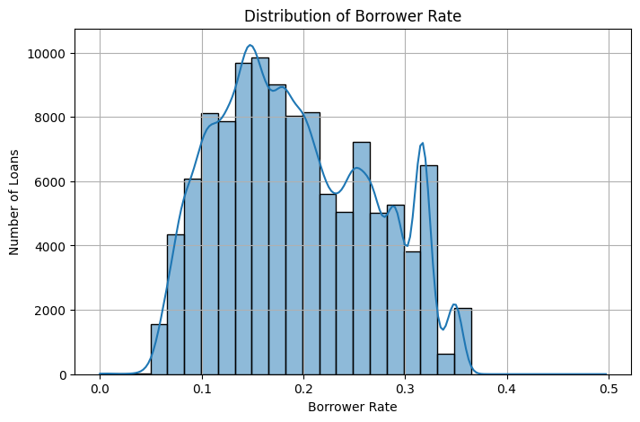

```python
import seaborn as sns
import matplotlib.pyplot as plt

plt.figure(figsize=(8,5))
sns.histplot(data=df, x='BorrowerRate', bins=30, kde=True)
plt.title('Distribution of Borrower Rate')
plt.xlabel('Borrower Rate')
plt.ylabel('Number of Loans')
plt.grid(True)
plt.show()
```

# 2. Distribution of Loan Amounts (Histogram)

### ❓ Question: What is the distribution of loan amounts?

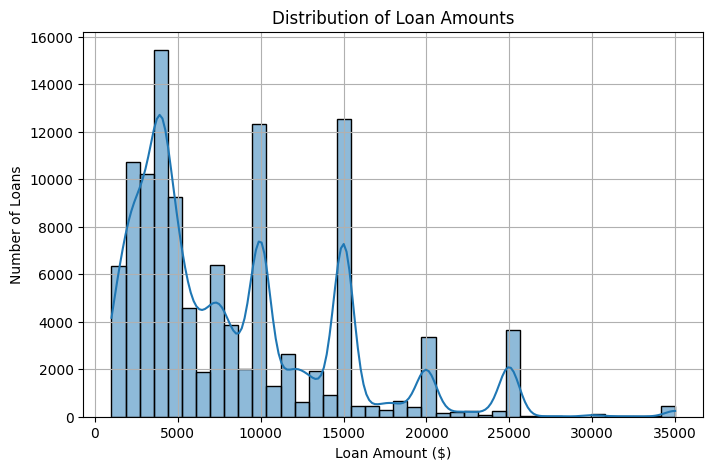

```python
plt.figure(figsize=(8,5))
sns.histplot(data=df, x='LoanOriginalAmount', bins=40, kde=True)
plt.title('Distribution of Loan Amounts')
plt.xlabel('Loan Amount ($)')
plt.ylabel('Number of Loans')
plt.grid(True)
plt.show()
```

**Observation:**  
The loan amount distribution shows distinct peaks around specific values such as $4,000, $10,000, and $15,000. These values are likely pre-set loan options. Most loans fall between $2,500 and $15,000, with very few exceeding $25,000. The data is right-skewed with heavy clustering at standard loan sizes.

# 3. Income Range Countplot

### ❓ Question: How are borrowers distributed across income ranges?

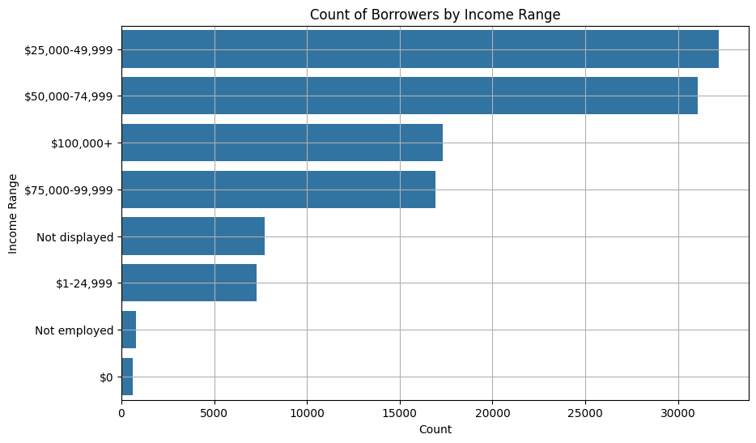

```python
plt.figure(figsize=(10,6))
order = df['IncomeRange'].value_counts().index
sns.countplot(data=df, y='IncomeRange', order=order)
plt.title('Count of Borrowers by Income Range')
plt.xlabel('Count')
plt.ylabel('Income Range')
plt.grid(True)
plt.show()
```

# 4. Loan Status Countplot

### ❓ Question: What are the most common loan statuses?

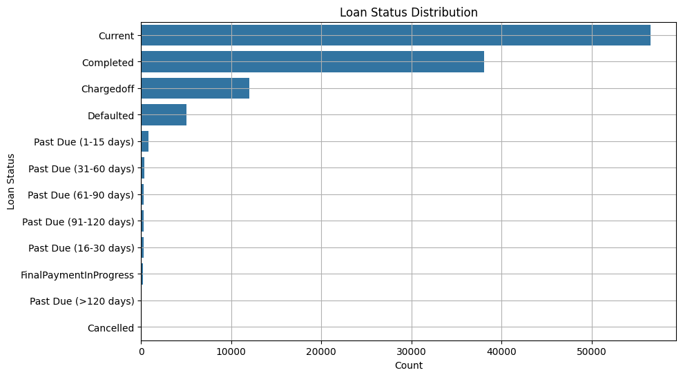

```python
plt.figure(figsize=(10,6))
order = df['LoanStatus'].value_counts().index
sns.countplot(data=df, y='LoanStatus', order=order)
plt.title('Loan Status Distribution')
plt.xlabel('Count')
plt.ylabel('Loan Status')
plt.grid(True)
plt.show()
```

**Observation:**  
Most loans in the dataset are either “Current” or “Completed,” indicating active or fully paid loans. Other loan statuses such as “Chargedoff” and “Defaulted” are much less common. This suggests a generally good repayment performance across the platform, with only a small portion of loans in delinquency or past due categories.

### Discuss the distribution(s) of your variable(s) of interest. Were there any unusual points? Did you need to perform any transformations?

> The borrower rate distribution is roughly bell-shaped with a peak between 0.15 and 0.2, indicating most borrowers are charged interest in that range. Loan amounts show strong right-skewness, with notable peaks at common requested amounts such as $4,000 and $10,000. While there were some outliers at higher loan amounts, no transformations were applied at this stage to preserve interpretability.

## Bivariate Exploration

> In this section, investigate relationships between pairs of variables in your data. Make sure the variables that you cover here have been introduced in some fashion in the previous section (univariate exploration).

# 1. Scatter Plot: Loan Amount vs. Borrower Rate

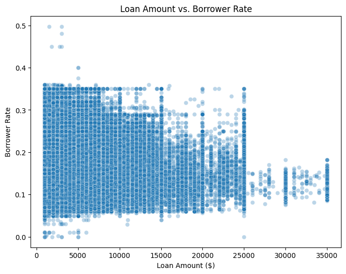

```python
plt.figure(figsize=(8,6))
sns.scatterplot(data=df, x='LoanOriginalAmount', y='BorrowerRate', alpha=0.3)
plt.title('Loan Amount vs. Borrower Rate')
plt.xlabel('Loan Amount ($)')
plt.ylabel('Borrower Rate')
plt.show()
```

Observation: There is a negative relationship between the loan amount and the borrower rate. Borrowers taking smaller loans tend to receive higher interest rates, while larger loans generally come with lower rates. There’s a dense cluster around the $5,000–$15,000 range, indicating this is the most common loan size.

# 2. Box Plot: Borrower Rate by Loan Status

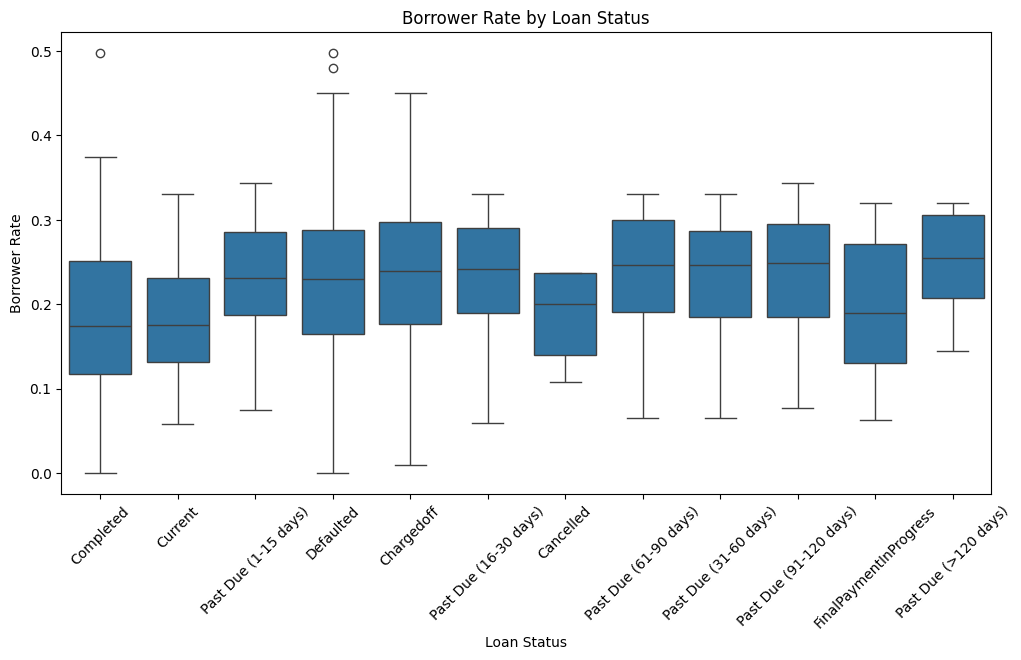

```python
plt.figure(figsize=(12,6))
sns.boxplot(data=df, x='LoanStatus', y='BorrowerRate')
plt.title('Borrower Rate by Loan Status')
plt.xlabel('Loan Status')
plt.ylabel('Borrower Rate')
plt.xticks(rotation=45)
plt.show()
```

# 3. Clustered Bar Chart: Loan Status by Income Range

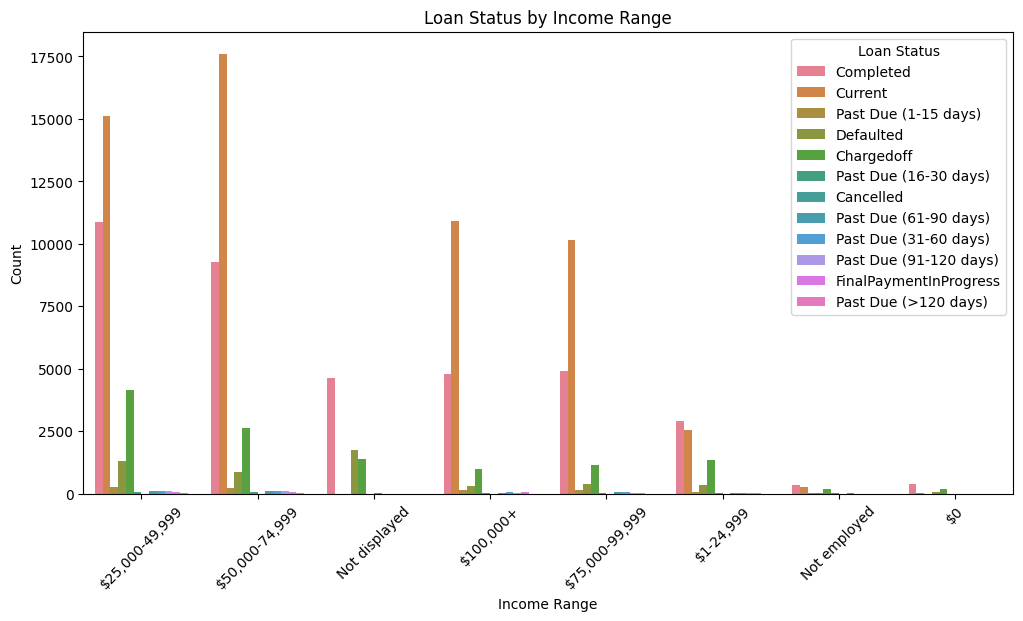

```python
plt.figure(figsize=(12,6))
sns.countplot(data=df, x='IncomeRange', hue='LoanStatus')
plt.title('Loan Status by Income Range')
plt.xlabel('Income Range')
plt.ylabel('Count')
plt.xticks(rotation=45)
plt.legend(title='Loan Status')
plt.show()
```

### Talk about some of the relationships you observed in this part of the investigation. How did the feature(s) of interest vary with other features in the dataset?

> In this analysis, the main feature of interest was the Borrower Rate. I observed that it has a negative relationship with the Loan Amount — borrowers requesting smaller loans tend to receive higher interest rates. Additionally, when analyzing Loan Status, borrowers with completed or current loans generally had lower borrower rates, while those with defaulted or past-due loans had significantly higher rates. This suggests that the interest rate is likely based on the perceived risk of the borrower.

## Multivariate Exploration

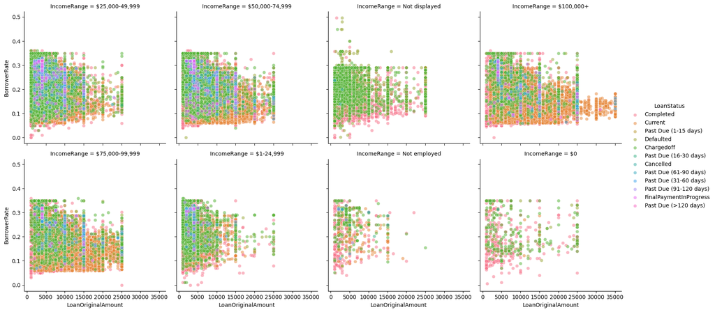

```python
import seaborn as sns
import matplotlib.pyplot as plt

# Create a FacetGrid to compare Borrower Rate vs Loan Original Amount
# across different Income Ranges, colored by Loan Status
g = sns.FacetGrid(data=df, col="IncomeRange", col_wrap=4, height=4, hue="LoanStatus")
g.map(sns.scatterplot, "LoanOriginalAmount", "BorrowerRate", alpha=0.5)

# Add legend to indicate Loan Status categories
g.add_legend()

# Show the plot
plt.show()
```

### Talk about some of the relationships you observed in this part of the investigation. Were there features that strengthened each other in terms of looking at your feature(s) of interest?

> By using FacetGrid to plot Borrower Rate vs. Loan Amount across different income ranges and colored by loan status, we observed that lower income ranges (e.g., "$1-24,999" and "$0") tend to have higher Borrower Rates regardless of the loan amount. This suggests that income level is a significant factor in determining the interest rate borrowers receive. In contrast, higher income groups (like "$100,000+") show a more concentrated range of lower Borrower Rates. Loan status helps confirm this relationship, as “Chargedoff” and “Defaulted” loans appear more frequently among low-income borrowers with higher rates.

### Were there any interesting or surprising interactions between features?

> One surprising pattern is how individuals with “Not Employed” or “Not displayed” income ranges still manage to receive loans, though often with higher Borrower Rates. Additionally, the variation in loan status across income groups shows that even high-income borrowers can have loans that are past due or defaulted, indicating that income alone doesn't guarantee repayment success. The spread of Loan Amounts is also wider for high-income borrowers, possibly reflecting higher borrowing capacity.

## Conclusions

### Summary of Main Findings

- **Borrower Rate & Loan Amount**: Lower-income individuals tend to receive loans with higher borrower rates, while higher-income individuals have access to lower rates, even with higher loan amounts.
- **Loan Status Impact**: “Chargedoff” and “Defaulted” loans were more common among low-income borrowers and those with high interest rates.
- **Feature Relationships**: Strong relationships were found between income range, borrower rate, and loan status.
- **Unexpected Patterns**: Even some high-income borrowers had defaulted loans, and unemployed individuals were still approved for loans, often at higher rates.
- **Visualization Insights**: FacetGrid and scatter plots were effective in highlighting multivariate interactions across income, loan amount, and status.